# rock_paper_scissors_classifier

## Installation

```python
pip install -q tensorflow tensorflow-datasets
```

## Import libraries

```python
import tensorflow as tf
import tensorflow_datasets as tfds
from tensorflow import keras
import numpy as np
import matplotlib.pyplot as plt
```

## Get datasets

```python
tfds.list_builders()
```

[output not shown]

[output cut: 100 more lines]

```
 'voc',
 'wider_face',
 'wikihow',
 'wikipedia',
 'wmt14_translate',
 'wmt15_translate',
 'wmt16_translate',
 'wmt17_translate',
 'wmt18_translate',
 'wmt19_translate',
 'wmt_t2t_translate',
 'wmt_translate',
 'xnli',
 'xsum',
 'yelp_polarity_reviews']
```

#### Getting info on the dataset

The `info` can be used to print out basic information about the chosen datset

```python
builder = tfds.builder('rock_paper_scissors')
info = builder.info

info
```

```
tfds.core.DatasetInfo(
    name='rock_paper_scissors',
    version=3.0.0,
    description='Images of hands playing rock, paper, scissor game.',
    homepage='http://laurencemoroney.com/rock-paper-scissors-dataset',
    features=FeaturesDict({
        'image': Image(shape=(300, 300, 3), dtype=tf.uint8),
        'label': ClassLabel(shape=(), dtype=tf.int64, num_classes=3),
    }),
    total_num_examples=2892,
    splits={
        'test': 372,
        'train': 2520,
    },
    supervised_keys=('image', 'label'),
    citation="""@ONLINE {rps,
    author = "Laurence Moroney",
    title = "Rock, Paper, Scissors Dataset",
    month = "feb",
    year = "2019",
    url = "http://laurencemoroney.com/rock-paper-scissors-dataset"
    }""",
    redistribution_info=,
)
```

## Data Preprocessing

Split data into training and testing sets

```python
tfds.disable_progress_bar()
train_data = tfds.load(name='rock_paper_scissors', split = 'train')
test_data = tfds.load(name='rock_paper_scissors',split='test')
```

```
Downloading and preparing dataset rock_paper_scissors/3.0.0 (download: 219.53 MiB, generated: Unknown size, total: 219.53 MiB) to /root/tensorflow_datasets/rock_paper_scissors/3.0.0...
```

```
Shuffling and writing examples to /root/tensorflow_datasets/rock_paper_scissors/3.0.0.incomplete40RLP9/rock_paper_scissors-train.tfrecord
Shuffling and writing examples to /root/tensorflow_datasets/rock_paper_scissors/3.0.0.incomplete40RLP9/rock_paper_scissors-test.tfrecord
Dataset rock_paper_scissors downloaded and prepared to /root/tensorflow_datasets/rock_paper_scissors/3.0.0. Subsequent calls will reuse this data.
```

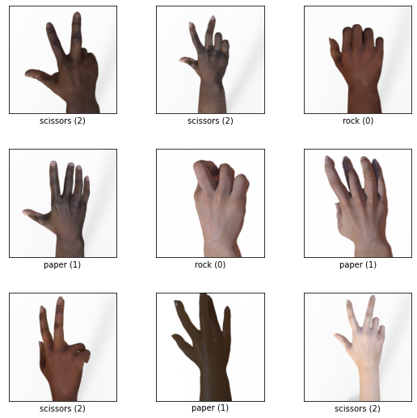

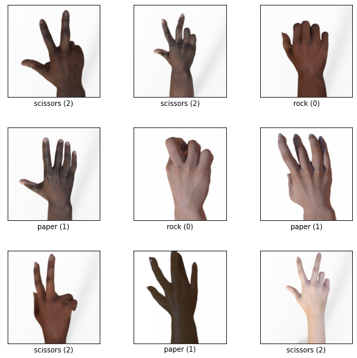

```python
tfds.show_examples(info, train_data)
```

### Extracting the images and labels from the train and test datasets

Here we extract the features and labels into different variables. We also convert the data frame that is in the form of Tensors to numpy arrays using `.numpy()` - a tensorflow function.  
Since colours aren't necessary for the dataset, we retain only the first of the three RGB channels (hence only R) using `[:,:,0]`. This allows us to retain the shape of the image as well as the first channel of its colours.  
Shape is in the form *(height, width, colour-channels)*  
Image and Label information can be found under the builder info tab. (Label consists of integers)

```python
train_images = np.array([examples['image'].numpy()[:,:,0] for examples in train_data])
train_labels = np.array([examples['label'].numpy() for examples in train_data])
```

```python
type(train_images)
```

```
numpy.ndarray
```

The cell below shows that there are 2520 single-channel images of width and height equal to 300.

```python
train_images.shape
```

```
(2520, 300, 300)
```

```python
test_images = np.array([examples['image'].numpy()[:,:,0] for examples in test_data])
test_labels = np.array([examples['label'].numpy() for examples in test_data])
```

**Converting the data type of the array values to float and normalising them between 0 and 1**

Not necessary but it is easier to work with when NN are concerned.

```python
# Adding the channel val. for grayscale.
train_images = train_images.reshape(2520, 300, 300, 1)
test_images = test_images.reshape(372, 300, 300, 1)

train_images = train_images.astype('float32')
test_images = test_images.astype('float32')

# converting range from 0-255 to 0-1
train_images /= 255
test_images /= 255
```

```python
train_images.dtype
```

```
dtype('float32')
```

```python
train_images[30].shape
```

```
(300, 300, 1)
```

## Neural Network Architecture

**Using simple Neural Network**

- Two Fully connected layers
- ReLu activation function at both FCs
- Softmax activation on Output layer with 3 nodes corresponding to Rock, Paper or Scissors

The image is first flattened from (300, 300, 1) to a one dim. array of 300x300x1 ( = 90,000)

```python
%%time
model = keras.Sequential([
                          keras.layers.Flatten(),
                          keras.layers.Dense(512, activation='relu'),
                          keras.layers.Dense(256, activation='relu'),
                          keras.layers.Dense(3, activation='softmax')
])

model.compile(optimizer='adam',
              loss=keras.losses.SparseCategoricalCrossentropy(),
              metrics=['accuracy'])

model.fit(train_images, train_labels, batch_size=32, epochs=5)
```

```
CPU times: user 8.18 s, sys: 2.49 s, total: 10.7 s
Wall time: 11.7 s
```

```python
model.evaluate(test_images, test_labels)
```

```
[1.8022669553756714, 0.4650537669658661]
```

**Using Convolutional Neural Networks**

- Two Convolutional Layers with a kernel_size of 3
- The input shape is in the form (batch_size,(shape)), where batch size is optional

```python
%%time
cnn_model = keras.Sequential([
                              keras.layers.Conv2D(64, kernel_size = 3, input_shape=(300,300,1),activation='relu'),
                              keras.layers.Conv2D(32, kernel_size = 3, activation='relu'),
                              keras.layers.Flatten(),
                              keras.layers.Dense(3, activation = 'softmax')
])

cnn_model.compile(optimizer='adam',
              loss=keras.losses.SparseCategoricalCrossentropy(),
              metrics=['accuracy'])

cnn_model.fit(train_images, train_labels, batch_size=32, epochs=5)
```

```
CPU times: user 1min 1s, sys: 29.5 s, total: 1min 30s
Wall time: 2min 11s
```

```python
cnn_model.evaluate(test_images, test_labels)
```

```
[1.6331827640533447, 0.524193525314331]
```

#### Improved CNN Model

```python
%%time
cnn_model_improved = keras.Sequential([
                              keras.layers.AveragePooling2D(6, strides=3, input_shape=(300,300,1)),
                              keras.layers.Conv2D(64, kernel_size = 3,activation='relu'),
                              keras.layers.Conv2D(32, kernel_size = 3, activation='relu'),
                              keras.layers.MaxPool2D(2, strides=2),
                              keras.layers.Dropout(0.5),
                              keras.layers.Flatten(),
                              keras.layers.Dense(128, activation='relu'),
                              keras.layers.Dense(3, activation = 'softmax')
])

cnn_model_improved.compile(optimizer='adam',
              loss=keras.losses.SparseCategoricalCrossentropy(),
              metrics=['accuracy'])

cnn_model_improved.fit(train_images, train_labels, batch_size=32, epochs=5)
```

```
CPU times: user 11.6 s, sys: 3.64 s, total: 15.3 s
Wall time: 18.5 s
```

```python
cnn_model_improved.evaluate(test_images, test_labels)
```

```
[1.4298378229141235, 0.6908602118492126]
```

### Hyperparameter Tuning

The basic architecture is the same but we add multiple options for the Convolutional and Dense layers using the *Choice* or *Int*.

For the Convolutional layer, we choose between zero and 3 layers. The tuner automatically selects the most optimal number of layers to define. With the Dense layers, we specify different possible number of nodes at each layer, and here too the tuner selects the optimum number.

```python
pip install -q -U keras-tuner
```

```python
from kerastuner.tuners import RandomSearch

def build_model(hp):
  model = keras.Sequential()

  model.add(keras.layers.AveragePooling2D(6, 3, input_shape=(300,300,1)))

  for i in range(hp.Int("Conv Layers", min_value=0, max_value=3)):
    model.add(keras.layers.Conv2D(hp.Choice(f"layer_{i}_filters",[16, 32, 64]),kernel_size=3, activation='relu'))

  model.add(keras.layers.MaxPool2D(pool_size=2, strides=2))
  model.add(keras.layers.Dropout(0.5))
  model.add(keras.layers.Flatten())

  model.add(keras.layers.Dense(hp.Choice('Dense Layers',[64, 128, 512, 1024]), activation='relu'))

  model.add(keras.layers.Dense(3, activation='softmax'))


  model.compile(optimizer='adam',
                loss=keras.losses.SparseCategoricalCrossentropy(),
                metrics=['accuracy'])

  return model
```

```python
%%time
tuner = RandomSearch(
    build_model,
    objective = 'val_accuracy',
    max_trials = 32
)

tuner.search(train_images, train_labels,validation_data=(test_images, test_labels), epochs = 10, batch_size = 32)
```

```
INFO:tensorflow:Reloading Oracle from existing project ./untitled_project/oracle.json
```

```
INFO:tensorflow:Reloading Oracle from existing project ./untitled_project/oracle.json
```

Trial complete

Trial summary

|-Trial ID: 4692f1b643dde1193b59c87bc80b4b12

|-Score: 0.7231183052062988

|-Best step: 0

Hyperparameters:

|-Conv Layers: 2

|-Dense Layers: 64

|-layer_0_filters: 16

|-layer_1_filters: 16

Trial complete

Trial summary

|-Trial ID: 4479a9570e70fab9b1a893091fa42f59

|-Score: 0.7338709831237793

|-Best step: 0

Hyperparameters:

|-Conv Layers: 2

|-Dense Layers: 128

|-layer_0_filters: 32

|-layer_1_filters: 64

Trial complete

Trial summary

|-Trial ID: 99373d765b0e634f2c7078e13063c00f

|-Score: 0.7553763389587402

|-Best step: 0

Hyperparameters:

|-Conv Layers: 2

|-Dense Layers: 512

|-layer_0_filters: 16

|-layer_1_filters: 16

Trial complete

Trial summary

|-Trial ID: 12b7c1fabf990ec67b21e1a57d61d7f7

|-Score: 0.7311828136444092

|-Best step: 0

Hyperparameters:

|-Conv Layers: 1

|-Dense Layers: 1024

|-layer_0_filters: 64

|-layer_1_filters: 16

Trial complete

Trial summary

|-Trial ID: 0790c449e7ceb8a43c0d3d363056cf34

|-Score: 0.7634408473968506

|-Best step: 0

Hyperparameters:

|-Conv Layers: 1

|-Dense Layers: 64

|-layer_0_filters: 64

|-layer_1_filters: 16

Trial complete

Trial summary

|-Trial ID: d51296f55c4b0f15ab051362c9e460d0

|-Score: 0.7446236610412598

|-Best step: 0

Hyperparameters:

|-Conv Layers: 2

|-Dense Layers: 512

|-layer_0_filters: 32

|-layer_1_filters: 16

Trial complete

Trial summary

|-Trial ID: aa18ba03637e1c50fd7d59393be5ef02

|-Score: 0.7580645084381104

|-Best step: 0

Hyperparameters:

|-Conv Layers: 1

|-Dense Layers: 512

|-layer_0_filters: 16

|-layer_1_filters: 64

Trial complete

Trial summary

|-Trial ID: b2ca9834c2d10300634dad66c4574ce1

|-Score: 0.7150537371635437

|-Best step: 0

Hyperparameters:

|-Conv Layers: 3

|-Dense Layers: 512

|-layer_0_filters: 16

|-layer_1_filters: 64

|-layer_2_filters: 16

Trial complete

Trial summary

|-Trial ID: 0c36cc7175a4e96f597a3beb1efc6e18

|-Score: 0.725806474685669

|-Best step: 0

Hyperparameters:

|-Conv Layers: 3

|-Dense Layers: 512

|-layer_0_filters: 16

|-layer_1_filters: 32

|-layer_2_filters: 16

Trial complete

Trial summary

|-Trial ID: f8ff7a2443c328e5c4e28893770fa2ef

|-Score: 0.3333333432674408

|-Best step: 0

Hyperparameters:

|-Conv Layers: 1

|-Dense Layers: 64

|-layer_0_filters: 16

|-layer_1_filters: 16

|-layer_2_filters: 32

Trial complete

Trial summary

|-Trial ID: 4b459e2db4bbf59e3a53868449359e5e

|-Score: 0.6102150678634644

|-Best step: 0

Hyperparameters:

|-Conv Layers: 0

|-Dense Layers: 1024

|-layer_0_filters: 32

|-layer_1_filters: 32

|-layer_2_filters: 32

Trial complete

Trial summary

|-Trial ID: 96ff4cf00d80c9584ac21b64928c288b

|-Score: 0.7715053558349609

|-Best step: 0

Hyperparameters:

|-Conv Layers: 2

|-Dense Layers: 512

|-layer_0_filters: 16

|-layer_1_filters: 16

|-layer_2_filters: 32

Trial complete

Trial summary

|-Trial ID: 9b51828ad643d64b8f560f9990fc2941

|-Score: 0.7553763389587402

|-Best step: 0

Hyperparameters:

|-Conv Layers: 1

|-Dense Layers: 512

|-layer_0_filters: 64

|-layer_1_filters: 32

|-layer_2_filters: 16

Trial complete

Trial summary

|-Trial ID: b6c40b5d34253ae5ccf7f398ad441821

|-Score: 0.7580645084381104

|-Best step: 0

Hyperparameters:

|-Conv Layers: 1

|-Dense Layers: 512

|-layer_0_filters: 32

|-layer_1_filters: 64

|-layer_2_filters: 16

Trial complete

Trial summary

|-Trial ID: d8e897e4715aad709783a6006a6761dd

|-Score: 0.5725806355476379

|-Best step: 0

Hyperparameters:

|-Conv Layers: 0

|-Dense Layers: 64

|-layer_0_filters: 32

|-layer_1_filters: 32

|-layer_2_filters: 16

Trial complete

Trial summary

|-Trial ID: 57771f0f1ad3a7be06871979e792880d

|-Score: 0.7043010592460632

|-Best step: 0

Hyperparameters:

|-Conv Layers: 2

|-Dense Layers: 1024

|-layer_0_filters: 16

|-layer_1_filters: 64

|-layer_2_filters: 16

Trial complete

Trial summary

|-Trial ID: 6817c4e437315dc5ca55a1ecb5bb80e3

|-Score: 0.7446236610412598

|-Best step: 0

Hyperparameters:

|-Conv Layers: 1

|-Dense Layers: 128

|-layer_0_filters: 64

|-layer_1_filters: 16

|-layer_2_filters: 16

Trial complete

Trial summary

|-Trial ID: 96965f02b6a4f9f6dd3461998ed45900

|-Score: 0.6209677457809448

|-Best step: 0

Hyperparameters:

|-Conv Layers: 1

|-Dense Layers: 64

|-layer_0_filters: 32

|-layer_1_filters: 16

|-layer_2_filters: 16

Trial complete

Trial summary

|-Trial ID: 378a8d21ae3147b530f3c64aa313f556

|-Score: 0.6397849321365356

|-Best step: 0

Hyperparameters:

|-Conv Layers: 0

|-Dense Layers: 1024

|-layer_0_filters: 16

|-layer_1_filters: 64

|-layer_2_filters: 64

Trial complete

Trial summary

|-Trial ID: 97d76270fc3803f65e112a4e60362593

|-Score: 0.774193525314331

|-Best step: 0

Hyperparameters:

|-Conv Layers: 2

|-Dense Layers: 512

|-layer_0_filters: 64

|-layer_1_filters: 16

|-layer_2_filters: 16

Trial complete

Trial summary

|-Trial ID: 5d31d8fa2eced89986149884dd52d1e9

|-Score: 0.6935483813285828

|-Best step: 0

Hyperparameters:

|-Conv Layers: 2

|-Dense Layers: 128

|-layer_0_filters: 16

|-layer_1_filters: 64

|-layer_2_filters: 16

Trial complete

Trial summary

|-Trial ID: 07f37dcbe5dd4197e725ad1c636b3402

|-Score: 0.7473118305206299

|-Best step: 0

Hyperparameters:

|-Conv Layers: 1

|-Dense Layers: 512

|-layer_0_filters: 64

|-layer_1_filters: 16

|-layer_2_filters: 64

Trial complete

Trial summary

|-Trial ID: a7e9cc63241ce8356f45b9a2b79da9c3

|-Score: 0.6935483813285828

|-Best step: 0

Hyperparameters:

|-Conv Layers: 1

|-Dense Layers: 128

|-layer_0_filters: 64

|-layer_1_filters: 64

|-layer_2_filters: 16

Trial complete

Trial summary

|-Trial ID: 49b4269b201b38346da5a357ae01f2c4

|-Score: 0.7822580933570862

|-Best step: 0

Hyperparameters:

|-Conv Layers: 3

|-Dense Layers: 512

|-layer_0_filters: 32

|-layer_1_filters: 16

|-layer_2_filters: 64

Trial complete

Trial summary

|-Trial ID: 1e6bd13ebea060e1861174315d384293

|-Score: 0.7284946441650391

|-Best step: 0

Hyperparameters:

|-Conv Layers: 2

|-Dense Layers: 512

|-layer_0_filters: 32

|-layer_1_filters: 64

|-layer_2_filters: 16

Trial complete

Trial summary

|-Trial ID: ce076a44312898debf233f61d94666e7

|-Score: 0.7607526779174805

|-Best step: 0

Hyperparameters:

|-Conv Layers: 1

|-Dense Layers: 512

|-layer_0_filters: 16

|-layer_1_filters: 16

|-layer_2_filters: 64

Trial complete

Trial summary

|-Trial ID: 61a0ec1d14a2a25d3a3960d80a58948b

|-Score: 0.6505376100540161

|-Best step: 0

Hyperparameters:

|-Conv Layers: 0

|-Dense Layers: 128

|-layer_0_filters: 16

|-layer_1_filters: 64

|-layer_2_filters: 32

Trial complete

Trial summary

|-Trial ID: 2b477d6bbcca73267efb90752085154f

|-Score: 0.7284946441650391

|-Best step: 0

Hyperparameters:

|-Conv Layers: 2

|-Dense Layers: 1024

|-layer_0_filters: 32

|-layer_1_filters: 16

|-layer_2_filters: 32

Trial complete

Trial summary

|-Trial ID: 2c2e4623d1bed8f7061dd47e665166a1

|-Score: 0.7903226017951965

|-Best step: 0

Hyperparameters:

|-Conv Layers: 1

|-Dense Layers: 512

|-layer_0_filters: 32

|-layer_1_filters: 64

|-layer_2_filters: 64

Trial complete

Trial summary

|-Trial ID: 808715a830dceb6b4a0ad4ccc6a15887

|-Score: 0.7607526779174805

|-Best step: 0

Hyperparameters:

|-Conv Layers: 1

|-Dense Layers: 128

|-layer_0_filters: 32

|-layer_1_filters: 64

|-layer_2_filters: 64

Trial complete

Trial summary

|-Trial ID: 783e36de4c849613b0e190bbc376067a

|-Score: 0.6209677457809448

|-Best step: 0

Hyperparameters:

|-Conv Layers: 0

|-Dense Layers: 1024

|-layer_0_filters: 64

|-layer_1_filters: 16

|-layer_2_filters: 32

Trial complete

Trial summary

|-Trial ID: 7b3265137b53dd3dedb4159729144d29

|-Score: 0.7876344323158264

|-Best step: 0

Hyperparameters:

|-Conv Layers: 1

|-Dense Layers: 1024

|-layer_0_filters: 16

|-layer_1_filters: 32

|-layer_2_filters: 16

```
INFO:tensorflow:Oracle triggered exit
```

```
INFO:tensorflow:Oracle triggered exit
```

```
CPU times: user 13min 6s, sys: 4min 19s, total: 17min 25s
Wall time: 23min 38s
```

```python
best_model = tuner.get_best_models()[0]
best_model.evaluate(test_images,test_labels)
```

```
[0.7096022963523865, 0.7903226017951965]
```

```python
best_model.summary()
```

```
Model: "sequential"
_________________________________________________________________
Layer (type)                 Output Shape              Param #
=================================================================
average_pooling2d (AveragePo (None, 99, 99, 1)         0
_________________________________________________________________
conv2d (Conv2D)              (None, 97, 97, 32)        320
_________________________________________________________________
max_pooling2d (MaxPooling2D) (None, 48, 48, 32)        0
_________________________________________________________________
dropout (Dropout)            (None, 48, 48, 32)        0
_________________________________________________________________
flatten (Flatten)            (None, 73728)             0
_________________________________________________________________
dense (Dense)                (None, 512)               37749248
_________________________________________________________________
dense_1 (Dense)              (None, 3)                 1539
=================================================================
Total params: 37,751,107
Trainable params: 37,751,107
Non-trainable params: 0
_________________________________________________________________
```

```python
tuner.results_summary()
```

Results summary

|-Results in ./untitled_project

|-Showing 10 best trials

|-Objective(name='val_accuracy', direction='max')

Trial summary

|-Trial ID: 2c2e4623d1bed8f7061dd47e665166a1

|-Score: 0.7903226017951965

|-Best step: 0

Hyperparameters:

|-Conv Layers: 1

|-Dense Layers: 512

|-layer_0_filters: 32

|-layer_1_filters: 64

|-layer_2_filters: 64

Trial summary

|-Trial ID: 7b3265137b53dd3dedb4159729144d29

|-Score: 0.7876344323158264

|-Best step: 0

Hyperparameters:

|-Conv Layers: 1

|-Dense Layers: 1024

|-layer_0_filters: 16

|-layer_1_filters: 32

|-layer_2_filters: 16

Trial summary

|-Trial ID: 49b4269b201b38346da5a357ae01f2c4

|-Score: 0.7822580933570862

|-Best step: 0

Hyperparameters:

|-Conv Layers: 3

|-Dense Layers: 512

|-layer_0_filters: 32

|-layer_1_filters: 16

|-layer_2_filters: 64

Trial summary

|-Trial ID: 97d76270fc3803f65e112a4e60362593

|-Score: 0.774193525314331

|-Best step: 0

Hyperparameters:

|-Conv Layers: 2

|-Dense Layers: 512

|-layer_0_filters: 64

|-layer_1_filters: 16

|-layer_2_filters: 16

Trial summary

|-Trial ID: 96ff4cf00d80c9584ac21b64928c288b

|-Score: 0.7715053558349609

|-Best step: 0

Hyperparameters:

|-Conv Layers: 2

|-Dense Layers: 512

|-layer_0_filters: 16

|-layer_1_filters: 16

|-layer_2_filters: 32

Trial summary

|-Trial ID: 0790c449e7ceb8a43c0d3d363056cf34

|-Score: 0.7634408473968506

|-Best step: 0

Hyperparameters:

|-Conv Layers: 1

|-Dense Layers: 64

|-layer_0_filters: 64

|-layer_1_filters: 16

Trial summary

|-Trial ID: ce076a44312898debf233f61d94666e7

|-Score: 0.7607526779174805

|-Best step: 0

Hyperparameters:

|-Conv Layers: 1

|-Dense Layers: 512

|-layer_0_filters: 16

|-layer_1_filters: 16

|-layer_2_filters: 64

Trial summary

|-Trial ID: 808715a830dceb6b4a0ad4ccc6a15887

|-Score: 0.7607526779174805

|-Best step: 0

Hyperparameters:

|-Conv Layers: 1

|-Dense Layers: 128

|-layer_0_filters: 32

|-layer_1_filters: 64

|-layer_2_filters: 64

Trial summary

|-Trial ID: aa18ba03637e1c50fd7d59393be5ef02

|-Score: 0.7580645084381104

|-Best step: 0

Hyperparameters:

|-Conv Layers: 1

|-Dense Layers: 512

|-layer_0_filters: 16

|-layer_1_filters: 64

Trial summary

|-Trial ID: b6c40b5d34253ae5ccf7f398ad441821

|-Score: 0.7580645084381104

|-Best step: 0

Hyperparameters:

|-Conv Layers: 1

|-Dense Layers: 512

|-layer_0_filters: 32

|-layer_1_filters: 64

|-layer_2_filters: 16

**Save and Load models**

```python
best_model.save('./my_model')
```

```
WARNING:tensorflow:From /usr/local/lib/python3.6/dist-packages/tensorflow/python/ops/resource_variable_ops.py:1817: calling BaseResourceVariable.__init__ (from tensorflow.python.ops.resource_variable_ops) with constraint is deprecated and will be removed in a future version.
Instructions for updating:
If using Keras pass *_constraint arguments to layers.
```

```
WARNING:tensorflow:From /usr/local/lib/python3.6/dist-packages/tensorflow/python/ops/resource_variable_ops.py:1817: calling BaseResourceVariable.__init__ (from tensorflow.python.ops.resource_variable_ops) with constraint is deprecated and will be removed in a future version.
Instructions for updating:
If using Keras pass *_constraint arguments to layers.
```

```
INFO:tensorflow:Assets written to: ./my_model/assets
```

```
INFO:tensorflow:Assets written to: ./my_model/assets
```

```python
loaded_model = keras.models.load_model('./my_model')
loaded_model.evaluate(test_images, test_labels)
```

```
[0.7096022963523865, 0.7903226017951965]
```

### Plotting images from numpy arrays

```python
# convert grayscale to rgb
rgb_images = np.array([example['image'].numpy() for example in train_data.take(5)]) # .take(5) takes only 5 images from the dataset...makes things quicker to test
rgb_image = rgb_images[0]
```

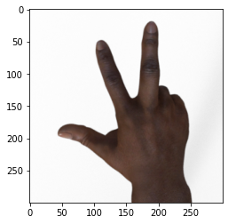

```python
plt.imshow(rgb_image)
```

```python
print(rgb_image.shape)
print(rgb_images.shape)
```

```
(300, 300, 3)
(5, 300, 300, 3)
```

**Converting PNG/JPG images to numpy arrays**

```python
import imageio
img = imageio.imread('https://upload.wikimedia.org/wikipedia/commons/2/25/Various_products_made_from_paper.JPG')
```

[figure not shown]

```python
plt.imshow(img)
```

```python
img_np = np.asarray(img)
img_np.shape
```

```
(3000, 4000, 3)
```

```python
print(type(img))
print(type(img_np))
```

```
<class 'imageio.core.util.Array'>
<class 'numpy.ndarray'>
```